# Honours project: Exploration of Judicial Facial Expression in Videos and Transcripts of Legal Proceedings

## Stage 1: Obtaining data

The source data of the proeject are videos from the high court of Australia (http://www.hcourt.gov.au/cases/recent-av-recordings). Turning the video information into tidy facial data can be summarised through the following workflow:

[figure not shown]

The revelent R code can be found in [2.Magick & OpenFace.Rmd](https://github.com/huizezhang-sherry/ETC4860/blob/master/2.Magick%20%26%20OpenFace.Rmd), 2.ffmpeg.Rmd and [3.0csv_proessing.Rmd](https://github.com/huizezhang-sherry/ETC4860/blob/master/3.0csv_processing.Rmd).

## Stage 2: Exploratory Data Analysis

### Missing value imputation

The missingness in the dataset could be due to the fact that a judge is reading the materials on the desk so the face is not captured for a particular frame or simply because some faces are not detectable for the given resolution of the video stream. However, since that data is in time series structure, simply drop the missing observation will cause the time interval to be irregular and complicate further analysis. There are two different sets of variables that need imputation: the ones end with `_c`, which is binary and the ones end with `_r`, which is a float number. Linear interpolation from `forecast` package is suitable to impute the variables end with `_r` and I sample from binomial distribution to impute the variables end with `_c`. More details in 3.1missing.Rmd.

### Exploratory data analysis

R markdown ducument 3.2EDA_nauru_a.Rmd records the analysis above. An extension to the full video EDA can be boudn [here](https://github.com/huizezhang-sherry/ETC4860/blob/master/3.3EDA.Rmd).

### Text Analysis

Text analysis conducted using the transcript strapped from the high court of Australia to study the interruptions by the justices. This is used as a benchmark to compare if facial information could help to understand more about Justices’ decisions. See [3.5text&outcome.R](https://github.com/huizezhang-sherry/ETC4860/blob/master/3.5%20text%26outcome.R) for more details.

## Stage 3: Action unit

### Data Structure

The rest of the project focuses on the action unit related variables. If we write all the information in the matrix notation, every element will have four indices:

- `i` for `judge_id`;
- `j` for `video_id`;
- `t` for `frame_id` and
- `k` for `au_id`.

Using the tidy principle, the data is in a tsibble format with `index = frame_id` and `key = c("judge_id, video_id)`. Different measurements on the presence and intensity of each action units are the variables.

Assuming all the facial information can be summarised as a `Y` variable with multiple indices `(i,j,t,k)`. We can summarise the information via a linear combination of variables as

[figure not shown]

where - CP_2 is the all possible interaction of the two variables - CP_3 is the all possible interaction of the three variables

### What can we learn from the action unit data

- **What are the most common action units for each judges?**

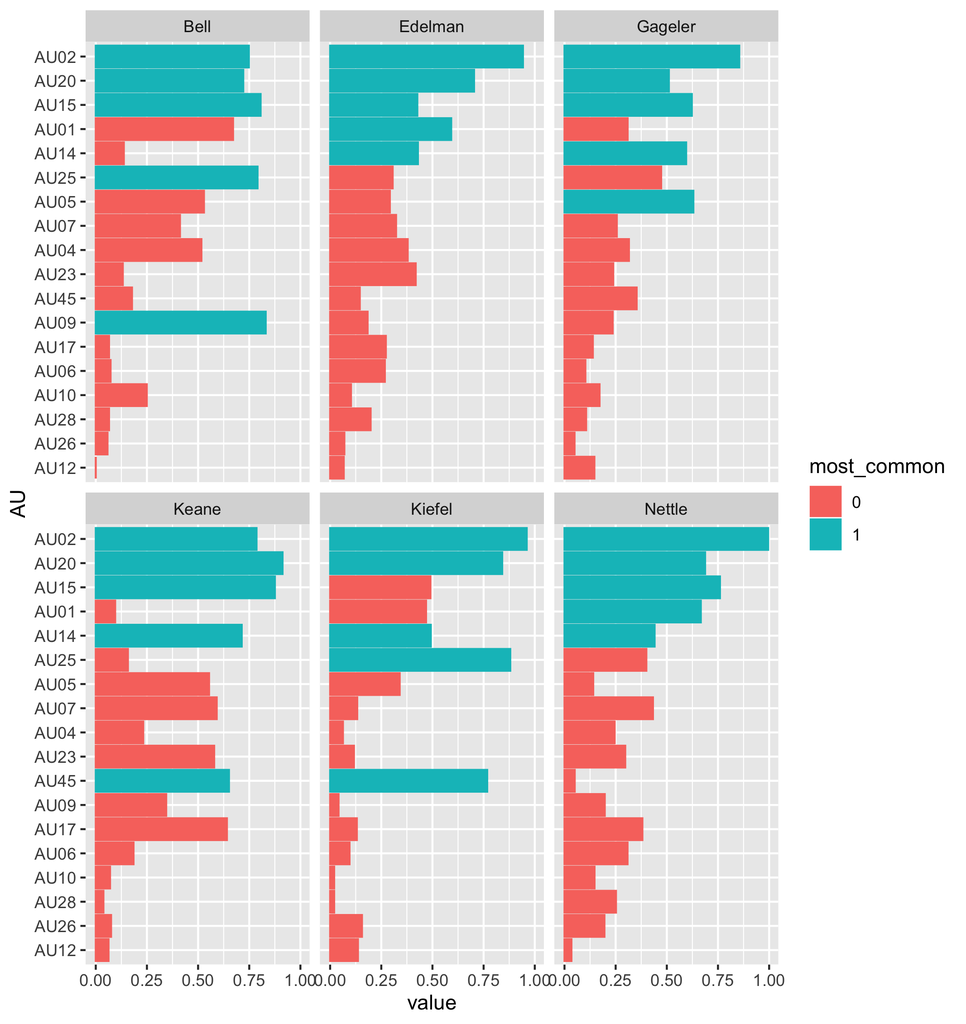

Rank by judge_id:

| index | Bell | Edelman | Gageler | Keane | Kiefel | Nettle |
| --- | --- | --- | --- | --- | --- | --- |
| 1 | AU09 | AU02 | AU02 | AU20 | AU02 | AU02 |
| 2 | AU15 | AU20 | AU05 | AU15 | AU25 | AU15 |
| 3 | AU25 | AU01 | AU15 | AU02 | AU20 | AU20 |
| 4 | AU02 | AU14 | AU14 | AU14 | AU45 | AU01 |
| 5 | AU20 | AU15 | AU20 | AU45 | AU14 | AU14 |

It can be seen that AU02(outer eyebrow raise) and AU20(lip stretcher) are both common for all the judges. AU15 and AU14 are also commonly detected for five out of the six judges. Other commonly displayed action units include: AU01, AU09, AU20, AU25 and AU45.

- **How does the intensity of action units looks like?**

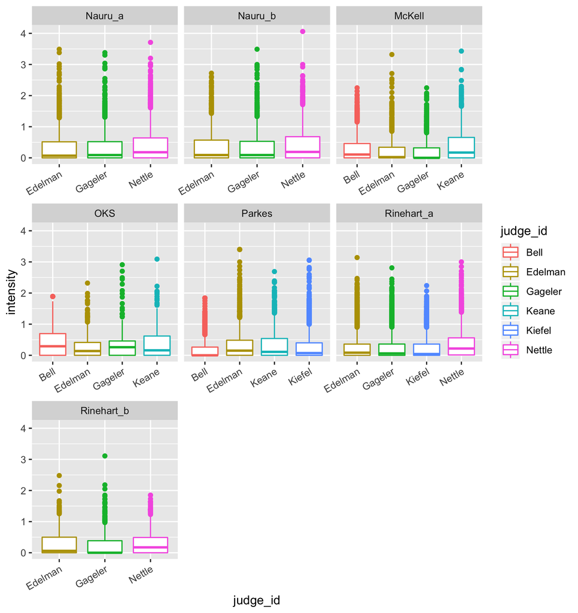

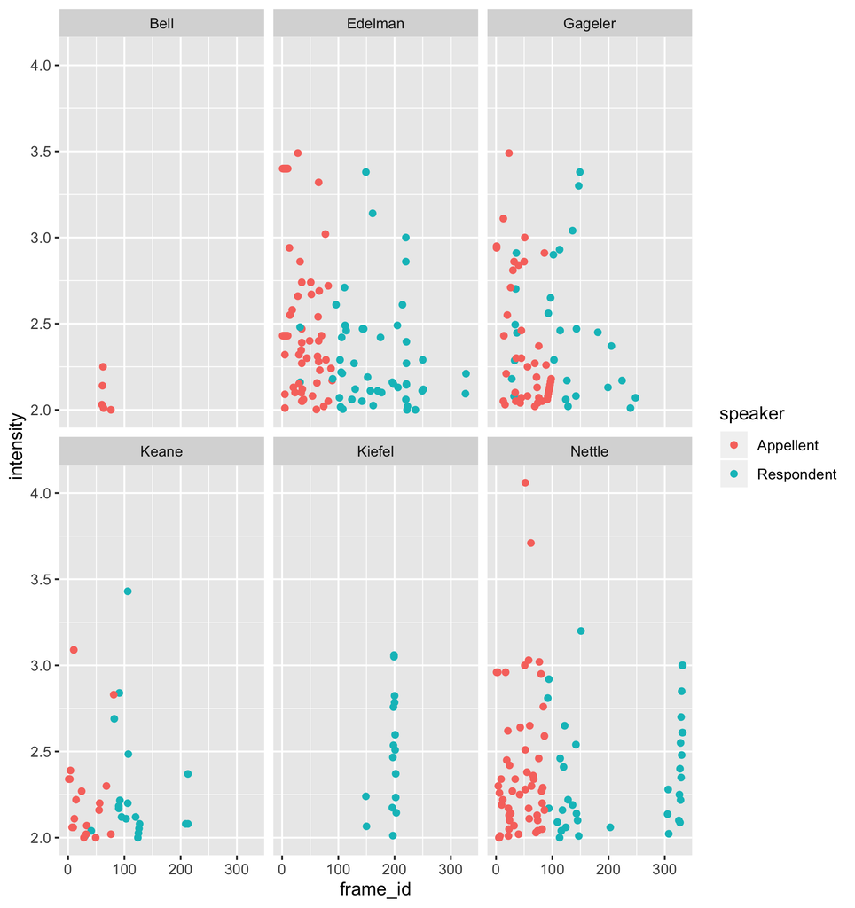

The points in the second plot are the one with intensity greater than 2. These are the points where the action units are slightly detected as per Ekman. It tells us that Edelman, Gageler and Nettle are the judges have stronger emotion that can be detected (since they have more points with intensity greater than 2). Different judges also have different time where they display stronger emotions. For example, Justice Nettle are more likely to have stronger emotion throughout the time when the appellent is speaking but only at the beginning and ending periold when the respondent is speaking.

## Stage 4: Action unit within judge

In this section, I use bootstrap simulation to answer the question

- *Does each Justice behave consistently in different trails or not?*

### AU presence

I first use simulation method to find the “normal” percentage of appearance of each AU for each Justices. The simulated mean percentage is then compared with the mean percentage appearance of each inidividual video to determine if an action unit appears considerably more or less than the “normal” level for each justices. The simulation and comparison procesure can be summarised as follows

- Step 1: Compute the simulated mean percentage appearance

[figure not shown]

  for each pair of

[figure not shown]

  using bootstrapping and binomial distribution. Below is an illustration of how bootstrap simulation is applied for *one particular* Justices-AU pair

[figure not shown]

  .
  - The replicates

[figure not shown]

    for bootstrap simulation are drawn from

[figure not shown]

  - The statistics to compute is the mean percentage:

[figure not shown]

  - Simulation result for all Justices-AU pair can be written in the matrix notation as

[figure not shown]

- Step 2: Compute the mean percentage appearance of each individual video

[figure not shown]

  for each combination of

[figure not shown]

The simulation result is presented here

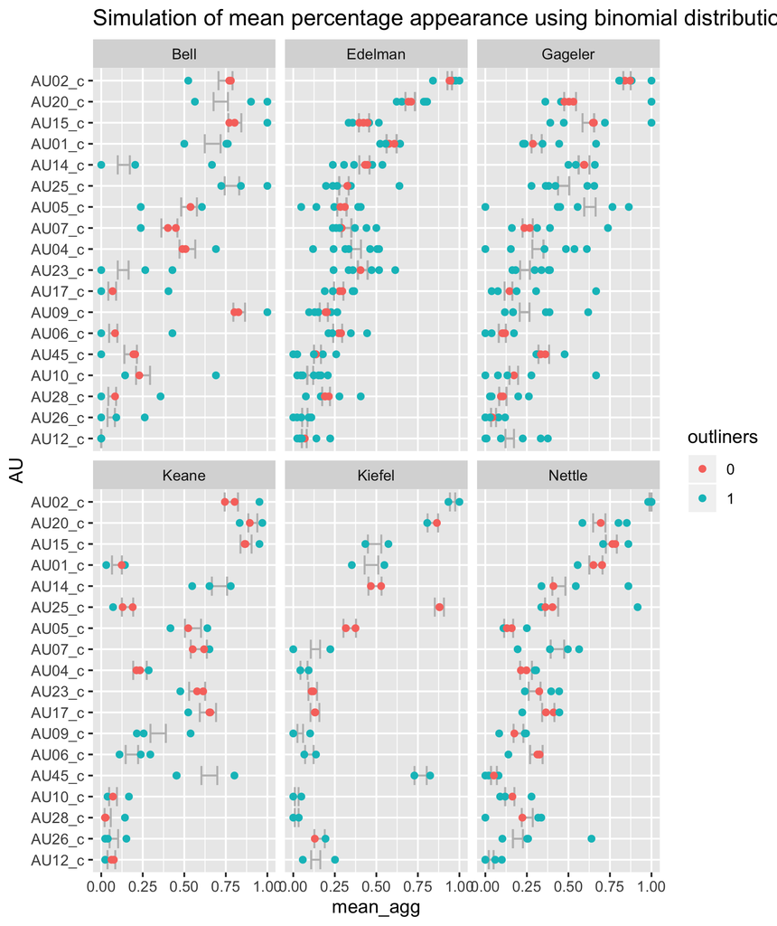

and

[figure not shown]

## Stage 5: Action unit between Judge

In this section, I use principle component analysis (PCA) to answer the question

- *Does the judges behave the same or different from one to another?*

Apart from understand how each Justice behaves consistently or not across all the videos, we are also interested in comparing *across* all the Justices to study who are more animated than others during the hearings. Time index is averaged for each judge and video pair and mathmetically, the matrix supplied to the PCA algorithm can be represented as follows.

[figure not shown]

The result of PCA can be summarised through the following visualisation.

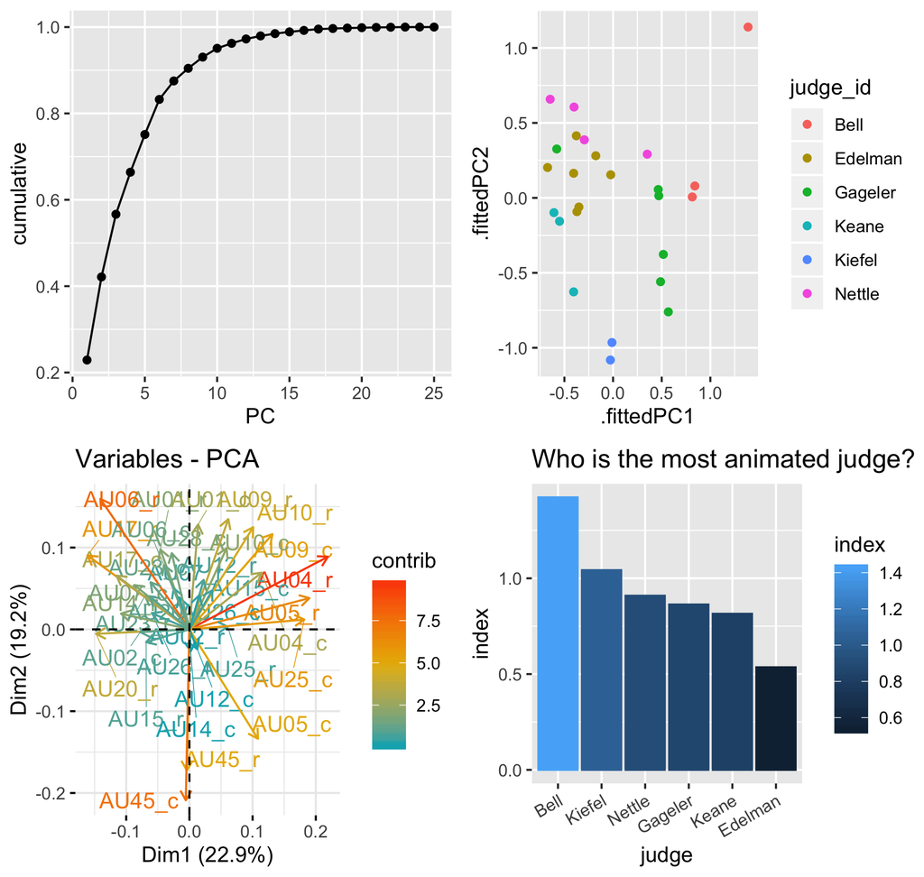

Since PCs are linear combination of the original variables, we take the absolute value of the fitted PCs and compute the sum to create an index. In this study, the first two fitted PCs are summed to determine the most animated judge and I find that Justices Bell is the most animated, then followed by the Chief Justices Kiefel and Justices Nettle. Edelman and Keane are the more nutural Justices.

The PCA exercise shows the most important linear combination of the action unit variables, which motivates us to find the most animated judge and thus help to build the judge profile. However, there are a few issues with the current PCA practice:

- The time index is averaged, thus can’t see how variables evolving over time
- The cumulated variance plot increase quite smoothly indicating the data itself is not very correlated.

## Stage 6: Emotion Profile

In this section, I create emotion profile for each of the judge to summarise their emotion characteristics in the hearing.

[output not shown]